# Simulation Testing Data Limited Methods **FLife**

Catch Only

25 August, 2019

# Introduction

This tutorial describes how to simuation test data limited methods in `FLR` using a variety of other packages.

## Required packages

To follow this tutorial you should have installed the following packages:

- FLR: [FLCore](http://www.flr-project.org/FLCore/), [FLBRP](http://www.flr-project.org/FLBRP/), [FLasher](http://www.flr-project.org/FLash/), [FLife](http://www.flr-project.org/FLife/)

# Operating Model

Turbot

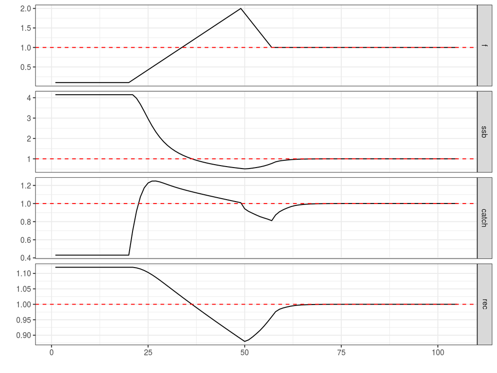

**Figure 1** Time series relative to MSY benchmarks.

# Catch Only Based Methods

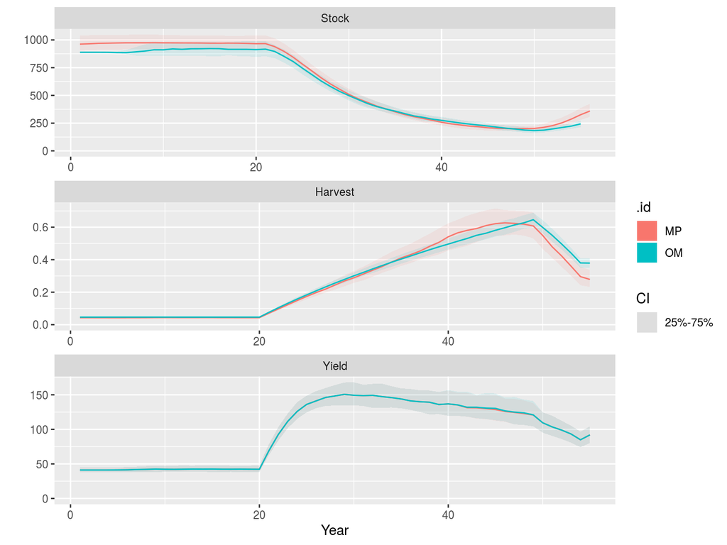

[figure not shown]

# More information

- You can submit bug reports, questions or suggestions on this tutorial at https://github.com/flr/doc/issues.
- Or send a pull request to https://github.com/flr/doc/
- For more information on the FLR Project for Quantitative Fisheries Science in R, visit the FLR webpage, http://flr-project.org.

## Software Versions

- R version 3.6.1 (2019-07-05)
- FLCore: 2.6.13
- FLasher: 0.5.3
- **Compiled**: Sun Aug 25 18:50:11 2019

## License

This document is licensed under the [Creative Commons Attribution-ShareAlike 4.0 International](https://creativecommons.org/licenses/by-sa/4.0) license.

## Author information

**Laurence KELL**. laurie@seaplusplus.co.uk

## Acknowledgements

This vignette and the methods documented in it were developed under the MyDas project funded by the Irish exchequer and EMFF 2014-2020. The overall aim of MyDas is to develop and test a range of assessment models and methods to establish Maximum Sustainable Yield (MSY) reference points (or proxy MSY reference points) across the spectrum of data-limited stocks.